# DS_Capstone

Ammar Al-Hawashem

11/6/2021

# **Part1: Introduction**

### What is the project?

The project is to build Machine Learning models that predict the number of attendance of each Weekly game of Suadi Professional League (SPL). 1861 games are used to build the models which represent all the attendance records since it became mandatory in 2010 until the suspension of the league due to COVID19 in 03/2020.

| Information | Description |
| --- | --- |
| Problem type | Supervised Regression |
| Response variable | The number of attendance of a weekly game |
| Features | 17 |
| Observations | 1861 |
| Objective | Use Some features to predict the attendance |

### What is the Goal of the project?

Can we predict the attendance of an SPL game? How does SPL attendance vary with changing the pre & within season variables?

### Who are the targeted audience?

This project can be useful for many sectors such as:

- The commercial campaigns to forecast the right time to publish a commercial.
- The home team to control the ticket prices and to forecast the right time to initialize some activities.
- The responsible committee within the Saudi Football federation to avoid scheduling matches at environmental conditions that may have negative effects to attendance number.

### What are the features?

| Variable | Description |
| --- | --- |
| 1- Week | The fixture (Round) [1-26] & [1-30] |
| 2- Home | The name of the home team |
| 3- Away | The name of the away team |
| 4-Venue | The stadium name |
| 5-Capacity | of the venue |
| 6-H_Followers | The number of twitter followers for the Home Team (assumed to be constant) |
| 7-A_Followers | The number of twitter followers for the Away Team (assumed to be constant) |
| 8-Rank_H | Position of Home Team before the this week (1-14) & (1-16) |
| 9-Rank_A | Position of Away Team before the this week |
| 10- RankDiff | The rank difference between the Home & Away Teams |
| 11-Period | Is it Daytime or night time (17:00 is used to separate) |
| 12-Weekend | Were the game played on a weekend day? (Thus, Fri, Sat + Holidays) |
| 13-TemperatureC | The temperature(Celsius) in the day and time of the match |
| 14-RH | % of Relative Humidity (estimated from the Temperature and Dew Point) |
| 15-Families | Were women were allowed to attend? (12-01-2018) |
| 16- LaggedAttendance | Attendance one home match earlier |
| 17- GameImp | Game importance (3 categories) |

### What is the target?

Attendance | The number of spectators in that game

### Resources

| Variable | Link |
| --- | --- |
| The Base Data | https://github.com/alioh/Saudi-Professional-League-Datasets |
| Attendance & Venue[1] | https://fbref.com/en/comps/70/749/schedule/2014-2015-Saudi-Professional-League-Scores-and-Fixtures |
| Attendance & Venue[2] | https://web.archive.org/web/20160705031432/http:/slstat.com/spl2010-2011ar/attendance.php |
| Ranks[1] | https://web.archive.org/web/20160721071334/http:/www.slstat.com/spl2013-2014ar/alltable.php |
| Ranks[2] | https://www.transfermarkt.com/saudi-professional-league/spieltagtabelle/wettbewerb/SA1/saison_id/2017/spieltag/2 |
| Temperature & Relative Humidity[1] | https://www.kaggle.com/esraamadi/saudi-arabia-weather-history |
| Temperature & Relative Humidity[2] | https://datasource.kapsarc.org/explore/dataset/saudi-hourly-weather-data |

### Load the necessary libraries

```r
library(tidyverse)
library(tidymodels)
library(gbm)      # for original implementation of regular and stochastic GBMs
library(h2o)      # for a java-based implementation of GBM variants
library(xgboost)  # for fitting extreme gradient boosting
library(rsample)
library(visdat)
library(naniar)   # To visualize missing values
library(GGally)
```

```r
library(corrplot)
library(themis)
library(ranger)
library(knitr)
library(rpart.plot)
library(chron)
library(lubridate) # To deal with dates and time
library(stringr)
library(stats)
library(vip)       # For the importance of features
library(finetune)  # To do tune_race_anova (a race method)
library(e1071)     # for skewness calculations
```

### Import the dataset

Let’s Load the dataset to our environment:

```r
SPL <- readr::read_csv("SPL_F1.csv")
```

# **Part2: Study the dataset**

### Skim the dataset

I Always like to use skimr::skim() to have a great view of the data:

```r
skimr::skim(SPL)
```

Data summary

| Name | SPL |
| --- | --- |
| Number of rows | 1861 |
| Number of columns | 28 |
| _______________________ |  |
| Column type frequency: |  |
| character | 7 |
| Date | 1 |
| difftime | 1 |
| numeric | 19 |
| ________________________ |  |
| Group variables | None |

**Variable type: character**

| skim_variable | n_missing | complete_rate | min | max | empty | n_unique | whitespace |
| --- | --- | --- | --- | --- | --- | --- | --- |
| Day | 0 | 1 | 6 | 9 | 0 | 7 | 0 |
| Home | 0 | 1 | 4 | 12 | 0 | 26 | 0 |
| Away | 0 | 1 | 4 | 12 | 0 | 26 | 0 |
| Venue | 0 | 1 | 18 | 45 | 0 | 22 | 0 |
| Families | 0 | 1 | 2 | 3 | 0 | 2 | 0 |
| Period | 0 | 1 | 5 | 7 | 0 | 2 | 0 |
| Weekend | 0 | 1 | 2 | 3 | 0 | 2 | 0 |

**Variable type: Date**

| skim_variable | n_missing | complete_rate | min | max | median | n_unique |
| --- | --- | --- | --- | --- | --- | --- |
| Date | 0 | 1 | 2010-08-14 | 2020-03-06 | 2015-09-20 | 753 |

**Variable type: difftime**

| skim_variable | n_missing | complete_rate | min | max | median | n_unique |
| --- | --- | --- | --- | --- | --- | --- |
| Time | 0 | 1 | 53100 secs | 81000 secs | 19:50:00 | 73 |

**Variable type: numeric**

| skim_variable | n_missing | complete_rate | mean | sd | p0 | p25 | p50 | p75 | p100 | hist |
| --- | --- | --- | --- | --- | --- | --- | --- | --- | --- | --- |
| Index | 0 | 1.00 | 931.00 | 537.37 | 1.00 | 466.00 | 931.00 | 1.396e+03 | 1861.00 | ▇▇▇▇▇ |
| Season | 0 | 1.00 | 2014.57 | 2.87 | 2010.00 | 2012.00 | 2015.00 | 2.017e+03 | 2019.00 | ▇▇▇▇▇ |
| Week | 0 | 1.00 | 13.52 | 7.62 | 1.00 | 7.00 | 13.00 | 2.000e+01 | 30.00 | ▇▇▇▇▃ |
| ScoreH | 0 | 1.00 | 1.56 | 1.32 | 0.00 | 1.00 | 1.00 | 2.000e+00 | 8.00 | ▇▅▁▁▁ |
| ScoreA | 0 | 1.00 | 1.36 | 1.19 | 0.00 | 0.00 | 1.00 | 2.000e+00 | 8.00 | ▇▅▁▁▁ |
| Attendance | 0 | 1.00 | 6314.24 | 9351.77 | 0.00 | 932.00 | 2902.00 | 7.620e+03 | 60134.00 | ▇▁▁▁▁ |
| Longitude | 0 | 1.00 | 45.15 | 3.64 | 39.16 | 43.95 | 45.37 | 4.684e+01 | 50.21 | ▆▁▇▇▇ |
| Latitude | 0 | 1.00 | 24.60 | 2.39 | 17.59 | 24.17 | 25.31 | 2.638e+01 | 30.01 | ▁▃▅▇▁ |
| Capacity | 0 | 1.00 | 27887.61 | 18518.20 | 500.00 | 20000.00 | 25000.00 | 2.755e+04 | 67000.00 | ▃▇▃▁▃ |
| H_Followers | 0 | 1.00 | 1405376.25 | 2547844.32 | 13100.00 | 91700.00 | 208700.00 | 2.000e+06 | 9600000.00 | ▇▂▁▁▁ |
| A_Followers | 0 | 1.00 | 1409027.46 | 2549057.54 | 13100.00 | 91700.00 | 208700.00 | 2.000e+06 | 9600000.00 | ▇▂▁▁▁ |
| Rank_H | 0 | 1.00 | 7.53 | 4.32 | 1.00 | 4.00 | 8.00 | 1.100e+01 | 16.00 | ▇▅▆▆▂ |
| Rank_A | 0 | 1.00 | 7.39 | 4.29 | 1.00 | 4.00 | 7.00 | 1.100e+01 | 16.00 | ▇▆▅▅▂ |
| TemperatureC | 0 | 1.00 | 24.82 | 7.42 | 5.00 | 19.00 | 25.00 | 3.060e+01 | 46.00 | ▂▆▇▆▁ |
| DewPoint | 0 | 1.00 | 8.17 | 8.23 | -19.00 | 2.00 | 8.00 | 1.400e+01 | 32.20 | ▁▃▇▅▁ |
| RH | 0 | 1.00 | 40.15 | 20.36 | 2.07 | 22.25 | 38.21 | 5.666e+01 | 100.00 | ▆▇▇▅▁ |
| LaggedAttendance | 148 | 0.92 | 6283.91 | 9062.13 | 0.00 | 1000.00 | 3020.00 | 7.715e+03 | 60134.00 | ▇▁▁▁▁ |
| RankDiff | 0 | 1.00 | 4.81 | 3.33 | 0.00 | 2.00 | 4.00 | 7.000e+00 | 15.00 | ▇▆▃▂▁ |
| GameImp | 0 | 1.00 | 1.02 | 0.18 | 1.00 | 1.00 | 1.00 | 1.000e+00 | 3.00 | ▇▁▁▁▁ |

### Convert s into factors

They’re are some factor featurees assigned as character so let’s convert them

```r
SPL$Families <- as.factor(SPL$Families)
SPL$Period <- as.factor(SPL$Period)
SPL$Weekend <- as.factor(SPL$Weekend)
SPL$GameImp <- as.factor(SPL$GameImp)
SPL$Season <- as.factor(SPL$Season)   #  not  a feature
```

Let’s focus in our features and target

```r
#1st let's git red of the only match that have 0 attendance as a penalty in both rhe attendance and the lagged attendance
#2nd: let's take just our features and target + the Date as an index that can be used


SPL %>%
  filter(Attendance>0,
         Index != 714
) %>%
  select(Date,
         Week,
         Home,
         Away,
         Venue,
         Capacity,
         H_Followers,
         A_Followers,
         Rank_H,
         Rank_A,
         Families,
         Period ,
         Weekend ,
         TemperatureC,
         RH,
         Attendance,
         LaggedAttendance,
         RankDiff,
         GameImp) -> SPL_DF
```

### How many observations have missing values?

```r
sum(is.na(SPL_DF))
```

```
## [1] 148
```

All of them for the lagged attendance as “skim” has shown

### Discover correlation

Discover the correlation between the features themselves and between them and the target.

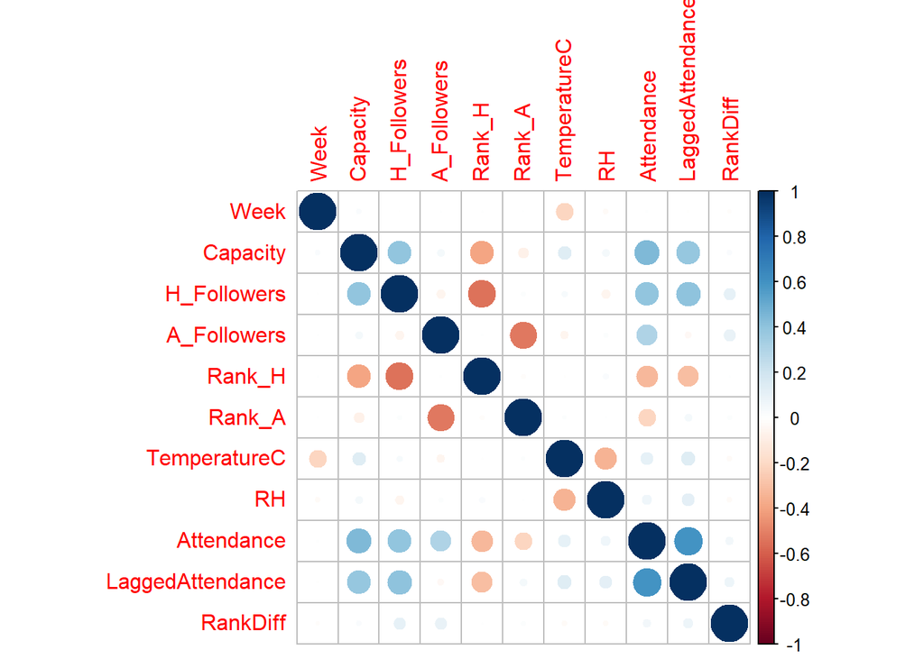

```r
# We have to exclude the NA's and the non numeric features
SPL_DF %>%
  filter(LaggedAttendance >0) %>%
  select_if(is.numeric) %>%
  cor() %>%
 corrplot()
```

we can notice that the Ranks correlates negatively with the followers (the leading teams have more twitter followers which makes sense). Moreovee and obvisuioly, there is a high correlation between the attendance nad the lagged one.

### Discover Skewness

To see if there are variables need to be transformed

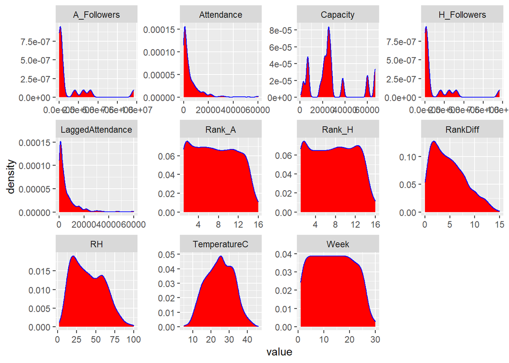

```r
SPL_DF %>%
  select(is.numeric) %>%
  gather() %>%
  ggplot(aes(value)) +
  facet_wrap(~ key, scales = "free")+
  geom_density(color = "blue", fill = "red")
```

```r
# Scale free will let ezch plot has its own appropriate x & y axis values
```

There are some variables that really right skewed

Let’s see what is the best transformation for each one

```r
SPL_DF %>%
  filter(Attendance >0, LaggedAttendance!=0) ->SPL1
#Skewness is estimated by using one of Joanes and Gill (1998) methods


#Choose the closest to 0 for each one

#Attendance
skewness(SPL1$Attendance, type = 2)
```

```
## [1] 3.05914
```

```r
skewness(log(SPL1$Attendance), type = 2)
```

```
## [1] -0.313298
```

```r
skewness(sqrt(SPL1$Attendance), type = 2)
```

```
## [1] 1.397702
```

```r
skewness((SPL1$Attendance)^(1/3), type = 2)
```

```
## [1] 0.8470838
```

```r
# Log is the lowest


#Lagged Attendance
skewness(SPL1$LaggedAttendance, type = 2)
```

```
## [1] 3.014057
```

```r
skewness(log(SPL1$LaggedAttendance), type = 2)
```

```
## [1] -0.3247907
```

```r
skewness(sqrt(SPL1$LaggedAttendance), type = 2)
```

```
## [1] 1.330254
```

```r
skewness((SPL1$LaggedAttendance)^(1/3), type = 2, na.rm = T )
```

```
## [1] 0.790836
```

```r
# Log is the lowest

# Twitter followers
skewness(SPL1$H_Followers, type = 2)
```

```
## [1] 2.319798
```

```r
skewness(log(SPL1$H_Followers), type = 2)
```

```
## [1] 0.517553
```

```r
skewness(sqrt(SPL1$H_Followers), type = 2)
```

```
## [1] 1.497062
```

```r
skewness((SPL1$H_Followers)^(1/3), type = 2)
```

```
## [1] 1.207643
```

```r
# Log is the lowest

# Capacity
skewness(SPL1$Capacity, type = 2)
```

```
## [1] 0.9254899
```

```r
skewness(log(SPL1$Capacity), type = 2)
```

```
## [1] -1.037921
```

```r
skewness(sqrt(SPL1$Capacity), type = 2)
```

```
## [1] 0.1169596
```

```r
skewness((SPL1$Capacity)^(1/3), type = 2)
```

```
## [1] -0.2260782
```

```r
# Square root is the lowest


# RankDifference
skewness(SPL1$RankDiff, type = 2)
```

```
## [1] 0.6364997
```

```r
skewness(log(SPL1$RankDiff), type = 2)
```

```
## [1] NaN
```

```r
skewness((SPL1$RankDiff)^(1/2), type = 2)
```

```
## [1] -0.01222669
```

```r
skewness((SPL1$RankDiff)^(1/3), type = 2)
```

```
## [1] -0.4639168
```

```r
# Square root is the lowest

# Relative Humidirity
skewness(SPL1$RH, type = 2)
```

```
## [1] 0.338173
```

```r
skewness(log(SPL1$RH), type = 2)
```

```
## [1] -0.6763448
```

```r
skewness(sqrt(SPL1$RH), type = 2)
```

```
## [1] -0.09868352
```

```r
skewness((SPL1$RH)^(1/3), type = 2)
```

```
## [1] -0.2664301
```

```r
# Square root is the lowest
```

Let’s apply the best transformation

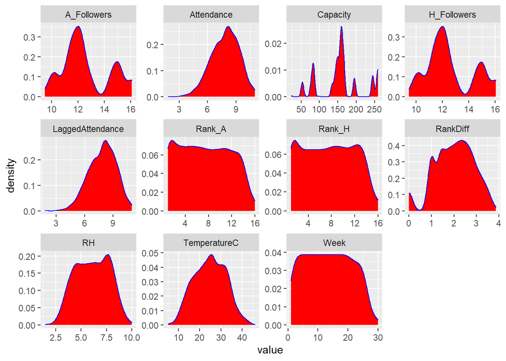

```r
SPL_DF %>%
  select(is.numeric) %>%
  mutate(Attendance = log(Attendance),
         LaggedAttendance = log(LaggedAttendance),
         A_Followers = log(A_Followers),
         H_Followers = log(H_Followers),
         Capacity = sqrt(Capacity),
         RH = sqrt(RH),
         RankDiff = sqrt(RankDiff)
                           ) %>%
  gather() %>%
  ggplot(aes(value)) +
  facet_wrap(~ key, scales = "free")+
  geom_density(color = "blue", fill = "red")
```

# **Part3: EDA**

Discover how the attendance changes with the rank & week

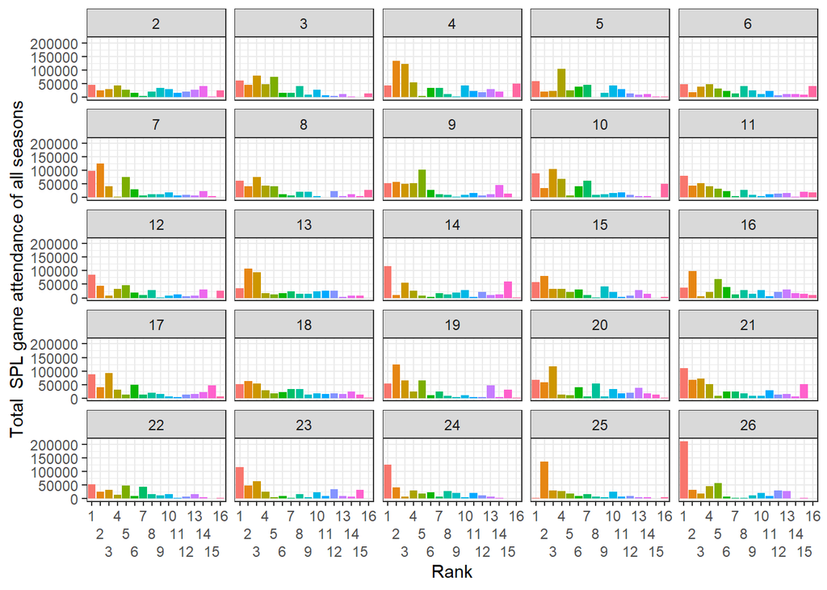

```r
#Need to be revised
SPL %>%
  mutate(Rank_H = factor(Rank_H)) %>%
  filter(Week >=2 & Week<=26) %>%
ggplot( aes(x=Rank_H, y=Attendance, fill=Rank_H))+
  geom_bar(stat='identity',show.legend = FALSE) +
  facet_wrap(~Week, ncol = 5) +
  theme_bw()+
  scale_x_discrete(guide = guide_axis(n.dodge=3))+
  labs(
    x = "Rank",
    y = "Total  SPL game attendance of all seasons")
```

```r
# HOW To make it include all the attendance
```

Discover how the attendance changes with changing the ranks of both Home & Away Teams

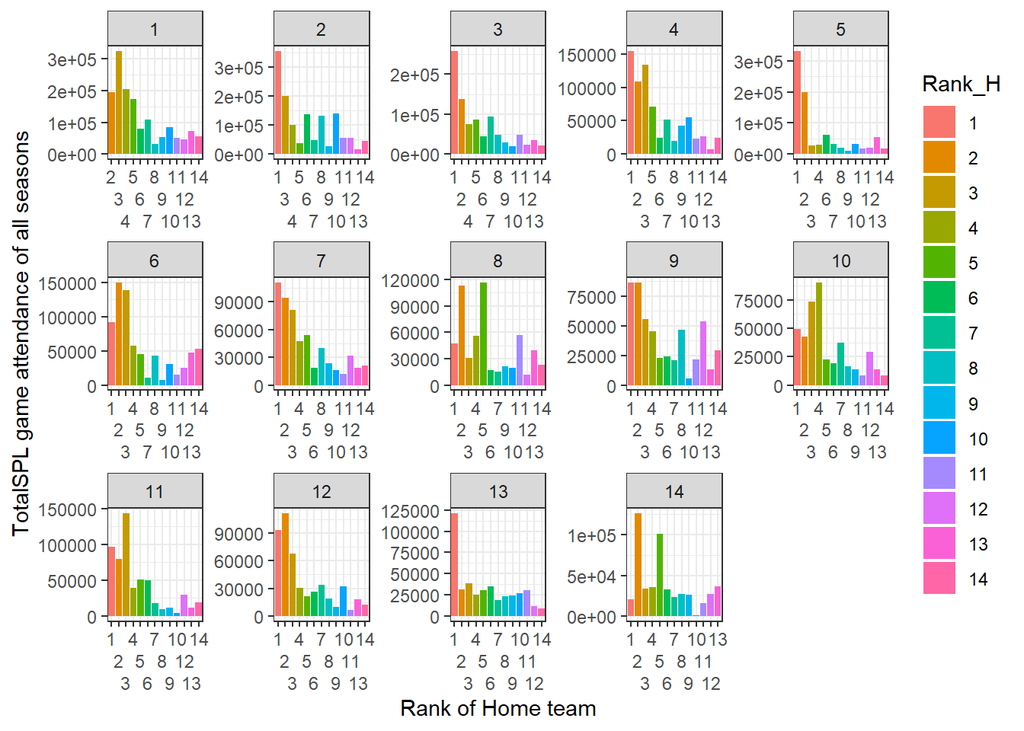

```r
SPL %>%
   filter(Rank_H <=14, Rank_A<=14) %>%
  mutate(Rank_H = factor(Rank_H)) %>%
  group_by(Rank_H, Rank_A) %>%
  filter( Rank_H !=Rank_A ) %>%
  summarise(Tot = sum(Attendance)) %>%
  ggplot( aes(x=Rank_H, y=Tot, fill=Rank_H))+
  geom_bar(stat='identity') +
  facet_wrap(~Rank_A, ncol = 5, scales = "free") +
  theme_bw()+
  scale_x_discrete(guide = guide_axis(n.dodge=3))+
  labs(
    x = "Rank of Home team",
    y = "TotalSPL game attendance of all seasons")
```

Discover how the attendance changes with the increase of twitter followers of the Home team

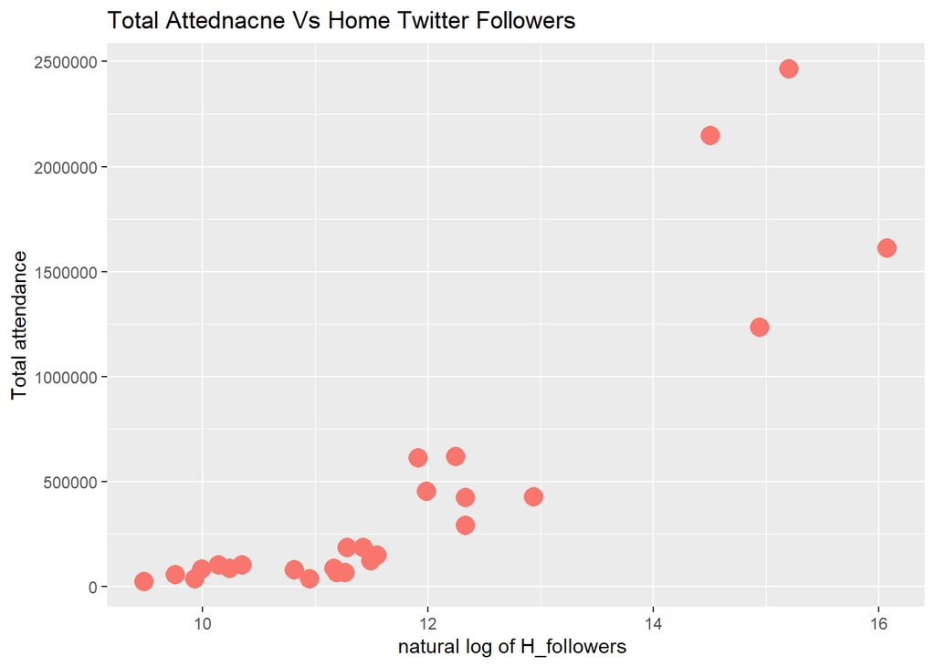

```r
SPL %>%
group_by(H_Followers) %>%
  summarise(Attendance = sum(Attendance)) -> WeeklyAtt


  ggplot(WeeklyAtt, aes(x=log(H_Followers),
                        y=Attendance,
                        color = "blue",
                        size = 3)) +
  geom_point(show.legend = FALSE, outlier.alpha = 0.5) +
  labs(
    x = "natural log of H_followers ",
    y = "Total attendance",
    title = "Total Attednacne Vs Home Twitter Followers")
```

Discover which Venues have high attendance average without counting for their capacities

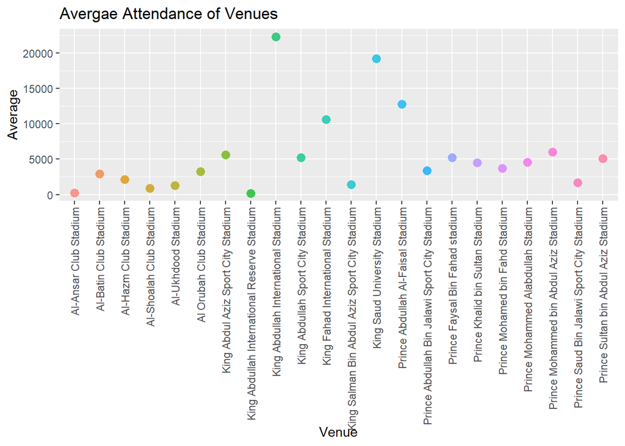

```r
SPL %>%
  group_by(Venue) %>%
  summarise(ToT = sum(Attendance)) -> tot
SPL %>%
  group_by(Venue) %>%
  count() -> SUM

tot %>%
  mutate( Games = SUM$n) -> mergeVenue
mergeVenue %>%
  mutate(Average = ToT/Games) %>%
  mutate(Venue = factor(Venue)) ->mergeVenue
remove(tot)

ggplot(mergeVenue, aes(x=Venue,
                 y=Average, color = Venue
                 ))+
         geom_point(alpha =0.75,
                    shape = 16,  show.legend = FALSE,
                    size = 3) +
  labs(title = "Avergae Attendance of Venues") +
  theme(axis.text.x = element_text(angle = 90, vjust = 0.5, hjust=1)) # This is to rotate the x labels since the names are long
```

Weekly attendance

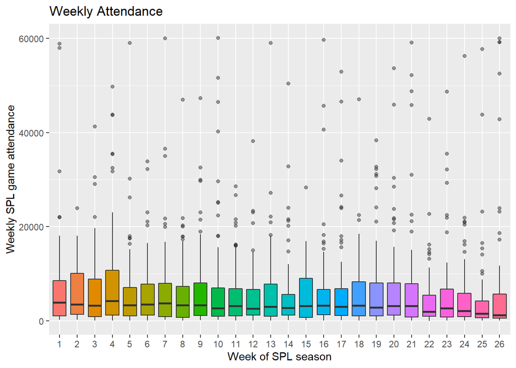

```r
SPL %>%
  filter(!Season =="s19") %>%
  filter(Week<27) %>%
     mutate(Week = factor(Week))->WeeklyAtt


  ggplot(WeeklyAtt, aes(x=Week, y=Attendance, fill =Week))+
  geom_boxplot(show.legend = FALSE, outlier.alpha = 0.5) +
  labs(
    x = "Week of SPL season",
    y = "Weekly SPL game attendance",
    title = "Weekly Attendance")
```

It was expected to have many extreme values since there are many other factors. However, ther are some interesting results with the IQR sucn as week 14, 22, & 26

Total Weekly Attendance

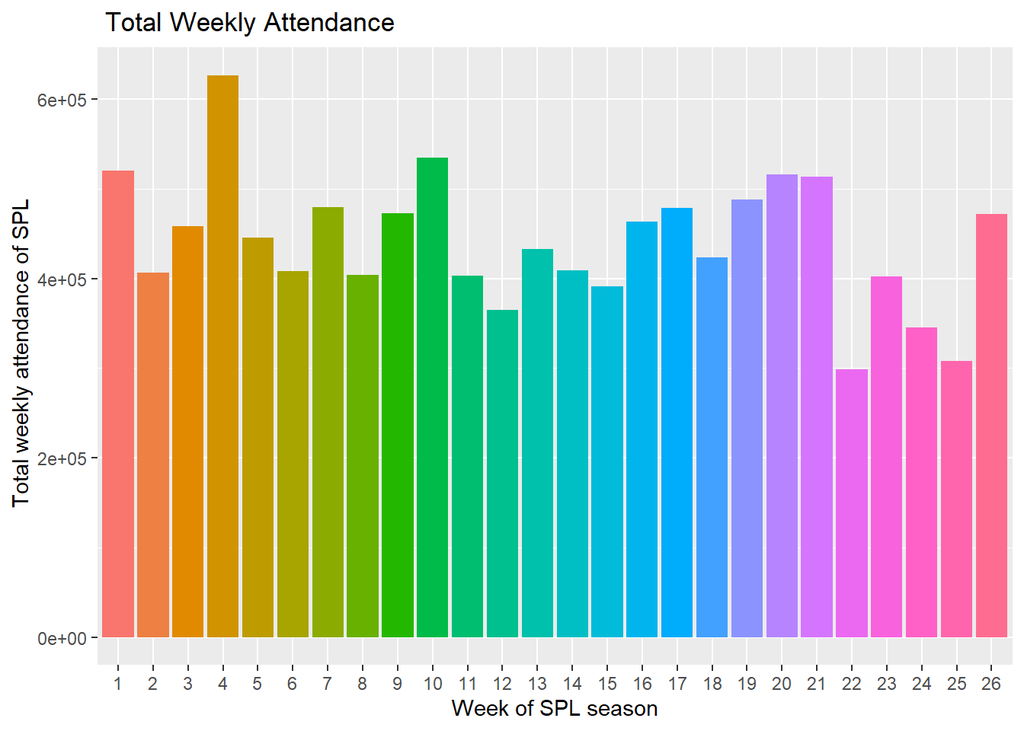

```r
SPL %>%
  filter(!Season =="s19") %>%
  filter(Week<27) %>%
  group_by(Week = factor(Week)) %>%
  summarise(Attendance = sum(Attendance)) -> WeeklyAtt


  ggplot(WeeklyAtt, aes(x=Week, y=Attendance, fill = Week)) +
  geom_bar(show.legend = FALSE, outlier.alpha = 0.5,stat='identity') +
  labs(
    x = "Week of SPL season",
    y = " Total weekly attendance of SPL",
    title = " Total Weekly Attendance")
```

- Week 4 represents an interesting result!
- Week 22 represents an unexpected result! since it is low
- Week 26 is expected since the champion usually will separate after the match, and if there were two teams still have hope to be the champion, the attendance will be higher.

Does weekend(Thursday-Friday,Saturday) have an effect?

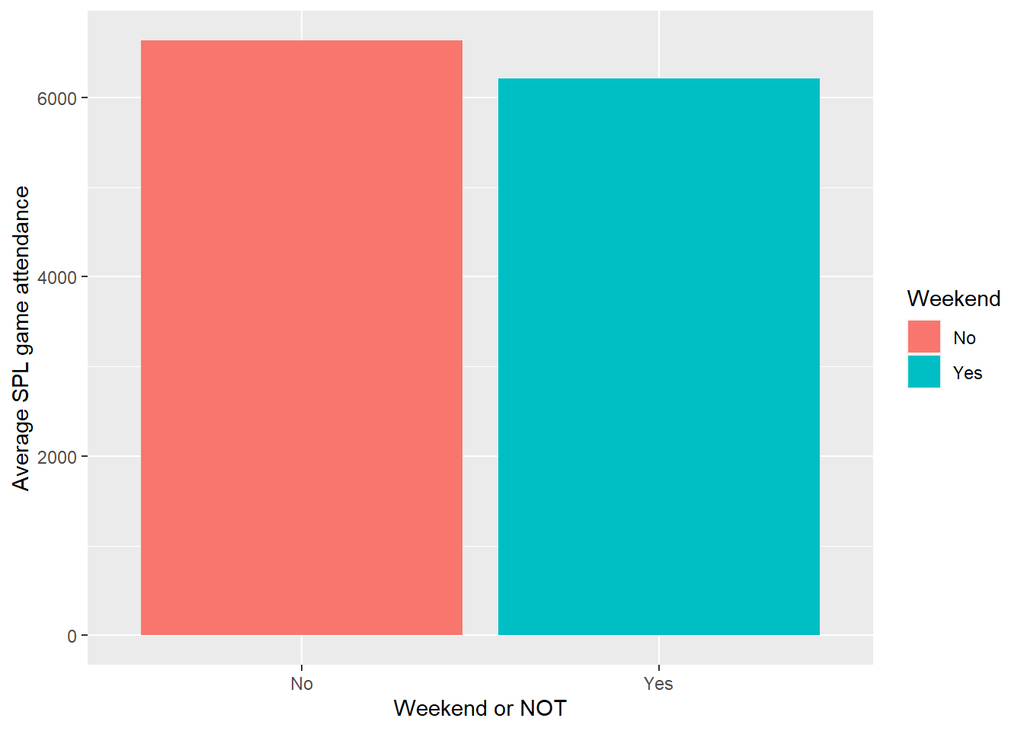

```r
SPL %>%
  group_by(Weekend) %>%
  summarise(ToT = sum(Attendance)) -> tot
SPL %>%
  group_by(Weekend) %>%
  count() -> SUM
tot %>%
  mutate( Games = SUM$n) -> mergeVenue
mergeVenue %>%
  mutate(Average = ToT/Games) ->mergeVenue
remove(tot)

  ggplot(mergeVenue, aes(x=Weekend, y=Average, fill =Weekend))+
geom_bar(stat='identity') +
  labs(
    x = "Weekend or NOT",
    y = "Average SPL game attendance")
```

Surprisingly, the average for the weekday is slightly higher than the weekend! However, Remember that they are imbalanced (460/1401).

Does the period (nighttime/daytime) have an effect?

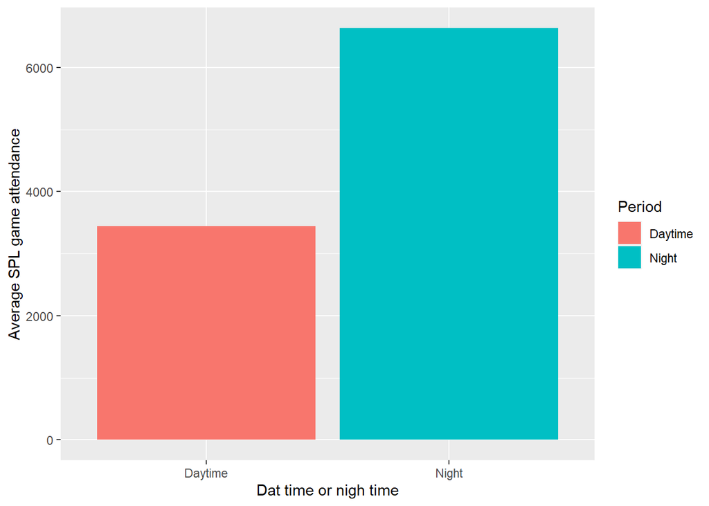

```r
SPL %>%
  group_by(Period) %>%
  summarise(ToT = sum(Attendance)) -> tot
SPL %>%
  group_by(Period) %>%
  count() -> SUM
tot %>%
  mutate( Games = SUM$n) -> mergeVenue
mergeVenue %>%
  mutate(Average = ToT/Games) ->mergeVenue
remove(tot)

  ggplot(mergeVenue, aes(x=Period, y=Average, fill =Period))+
geom_bar(stat='identity') +
  labs(
    x = "Dat time or nigh time",
    y = "Average SPL game attendance")
```

The attendance at nighttime is much higher than the attendance in the daytime.

Let’s now study both of them at the same time

```r
SPL %>%
  group_by(Weekend, Period) %>%
  summarise(ToT = sum(Attendance)) -> tot
```

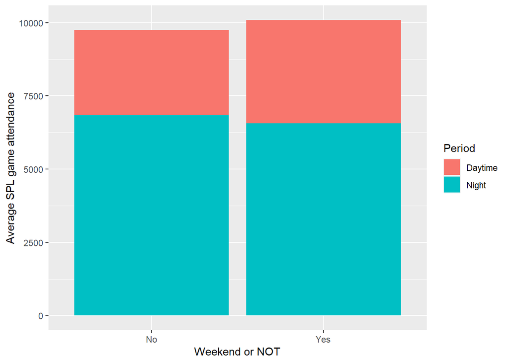

```r
SPL %>%
  group_by(Weekend, Period) %>%
  count() -> SUM
tot %>%
  add_column( Games = SUM$n) -> mergeVenue
mergeVenue %>%
  mutate(Average = ToT/Games) ->mergeVenue
remove(tot)

  ggplot(mergeVenue, aes(x=Weekend, y=Average, fill =Period))+
geom_bar(stat='identity') +
  labs(
    x = "Weekend or NOT",
    y = "Average SPL game attendance")
```

Conclusions: - The average attendance at nighttime is almost the same(slightly higher at nighttime) - The average attendance in daytime is higher in the weekends which is expected

Do women attendance have an effect?

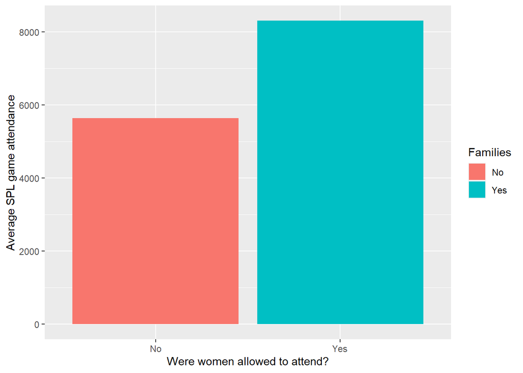

```r
SPL %>%
  group_by(Families) %>%
  summarise(ToT = sum(Attendance)) -> tot
SPL %>%
  group_by(Families) %>%
  count() -> SUM
tot %>%
  mutate( Games = SUM$n) -> mergeVenue
mergeVenue %>%
  mutate(Average = ToT/Games) ->mergeVenue
remove(tot)

  ggplot(mergeVenue, aes(x=Families, y=Average, fill =Families))+
geom_bar(stat='identity') +
  labs(
    x = "Were women allowed to attend?",
    y = "Average SPL game attendance")
```

Total attendance in each season

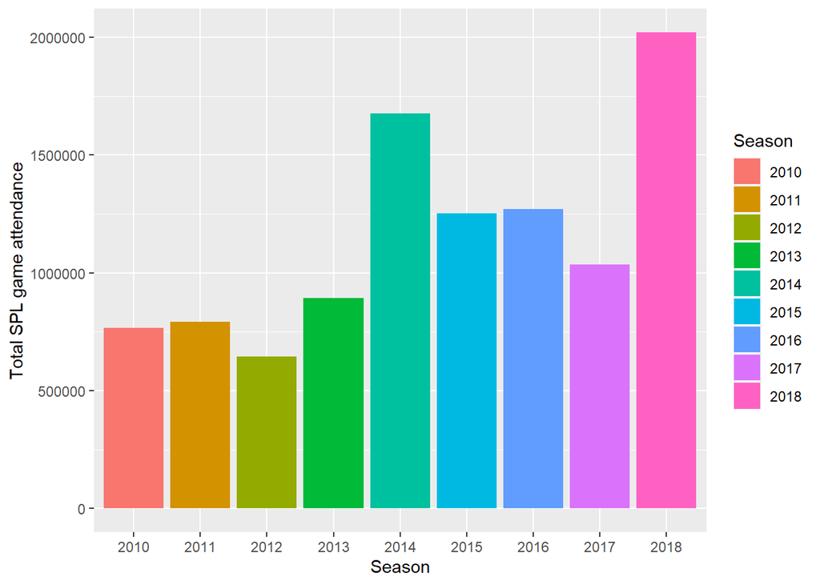

```r
SPL %>%
filter(!Season ==2019) %>%
  mutate(Home = factor(Home)) %>%
ggplot( aes(x=Season, y=Attendance, fill=Season))+
  geom_bar(stat='identity') +
  labs(
    x = "Season",
    y = "Total SPL game attendance")
```

As shown above, it seems women have a positive effect but remember that data are imbalanced and represents specific seasons. Therefore, since women introduced exactly at the middle of season 2017, let’s check it:

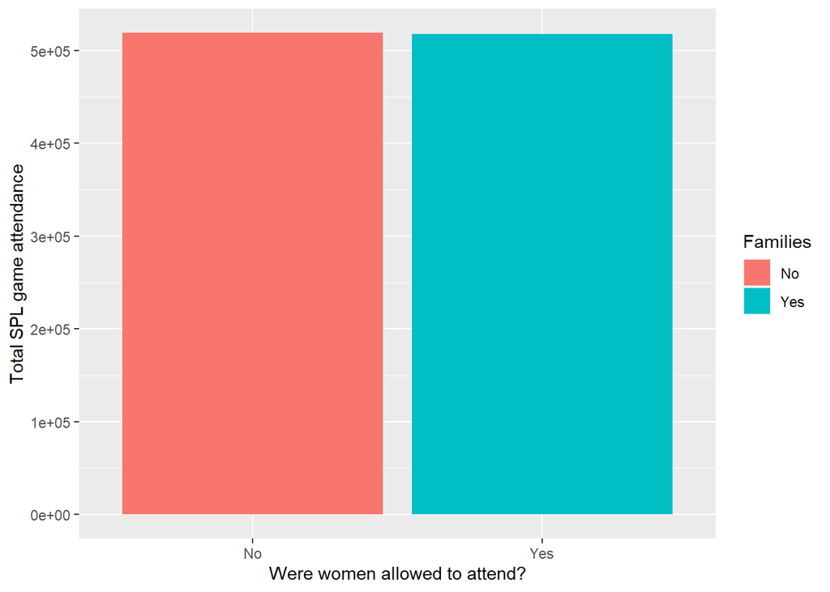

```r
SPL %>%
  filter(Season == 2017) %>%
  group_by(Families) %>%
  ggplot( aes(x=Families, y= Attendance, fill =Families))+
geom_bar(stat='identity') +
  labs(
    x = "Were women allowed to attend?",
    y = "Total SPL game attendance")
```

They are equal, so no conclusion neither to deny nor to confirm its effects